# Lab 2 Group

Henry Siegler

2022-04-15

```r
library(tidyverse)
library(readxl)
library(here)
library(leaflet)
library(rgdal)
```

# Part One: Identifying Bad Visualizations

## Disseting a Bad Visualization

**1**

The graph is showing us the percentage of people who believe that vaccines are safe for many different countries across the world. The countries are grouped into different major regions of the world, and each of these regions has a line that indicates the country that is the region’s median. I think the authors of the graph meant to demonstrate how people of different regions of the world compare in how they feel about vaccines in general. I think they also meant to convey how individual countries compare to other countries in their region for this statistic.

**2**

The variables that appear to be displayed in the visualization are the percent of people who believe vaccines are safe, country, and global region.

**3**

The aesthetic for the x axis is the percent of people who believe that vaccines are safe, the y axis aesthetic is global region, and there is a label aesthetic for country name.

**4**

I would call this graph a modified box plot because the points are only distributed for the x axis, which is a numeric variable. I would say it is modified because instead of showing the IQR and minimum and maximum values, it only shows the median value of the region and each individual country’s value.

**5**

The main problem with the graph is that the points seem to be graphed to a y axis value as well because the point increase in the y axis value as the percent of people who believe vaccines are safe increases. The y axis value does not represent anything, and it only makes the graph confusing to interpret. I would completely remove this increase in the y axis altogether. I would remove the legend at the bottom of the graph because the region name is displayed next to each region. Also, the graph only shows the country name for the countries that are close to the minimum or maximum value for the region, and they are sometimes very close together. I would remove these country labels because it makes the graph harder for the reader to analyze.

## Improving a Bad Visualization

```r
survey <- read_excel(here::here("wgm2018-dataset-crosstabs-all-countries.xlsx"),
                     sheet = "Full dataset")
```

```r
vaccines_data <- survey %>%
  filter(Q25 != 99) %>%
  select(WP5, Regions_Report, Q25) %>%
  mutate(safe = case_when(Q25 %in% 1:2 ~ 1,
                          TRUE ~ 0),
         region = case_when(Regions_Report %in% c(10, 11, 12, 18) ~ "Asia",

                            Regions_Report %in% c(3, 13) ~ "Middle East and North Africa",

                            Regions_Report %in% c(1, 2, 4, 5) ~ "Sub-Saharan Africa",

                            Regions_Report %in% 6:8 ~ "Americas",

                            Regions_Report %in% c(15, 16, 17 , 0) ~ "Europe",

                            Regions_Report %in% c(9, 14) ~ "Former Soviet Union"
                            ))

vaccines_data <- vaccines_data %>%
  group_by(WP5, region) %>%
  summarise(pct = mean(safe) * 100) %>%
  mutate(region = as.factor(region))
```

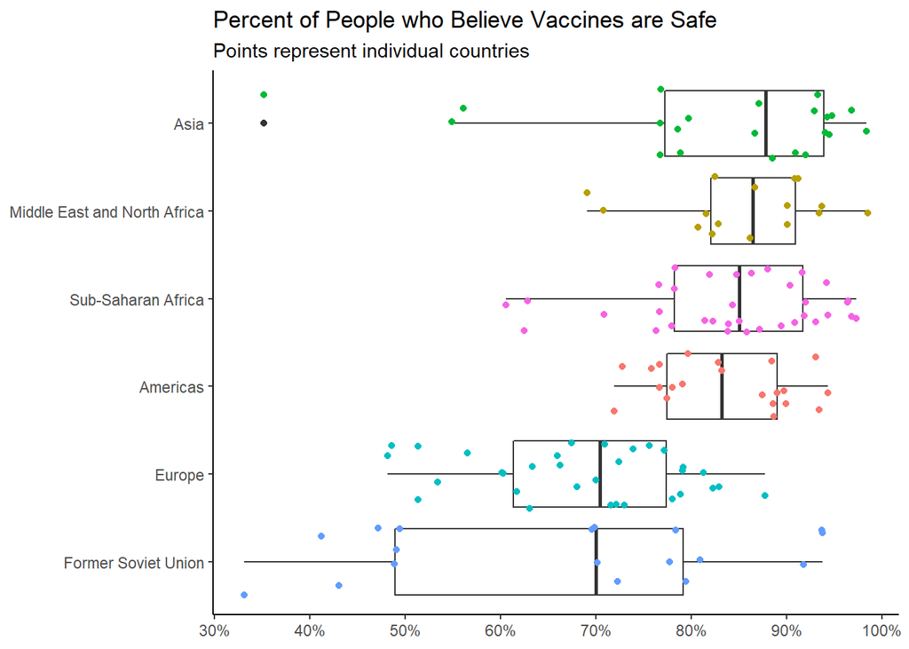

```r
vaccines_data %>%
  ggplot(aes(x = pct, y = reorder(region, pct, median))) +
  geom_boxplot() +
  geom_jitter(aes(color = region)) +
  theme_classic() +
  scale_color_discrete() +
  scale_x_continuous(breaks = seq(30, 100, by = 10),
                     labels = function(x) paste0(x, "%")) +
  ggtitle("Percent of People who Believe Vaccines are Safe") +
  labs(subtitle = "Points represent individual countries") +
  theme(legend.position = "none",
        axis.title = element_blank(),
        panel.grid.major.y = element_blank(),
        panel.grid.minor.x = element_blank())
```

# Part Two: Broad Visualization Improvement

## Second Data Visualization Improvement

**1** Select a data visualization in the report that you think could be improved. Be sure to cite both the page number and figure title. Do your best to tell the story of this graph in words. That is, what is this graph telling you? What do you think the authors meant to convey with it?

The choropleth on page 65 of the report can be improved. This graph uses varying shades of the color green to represent the level of confidence that people in particular countries have in their countries’ health clinics and hospitals.

**2** List the variables that appear to be displayed in this visualization. The variables that appear to be displayed in the visualization are country and level of confidence on hospitals and health care clinics.

**3** Now that you’re versed in the grammar of graphics (ggplot), list the aesthetics used and which variables are specified for each. The fill aesthetic is the country and the percentage of confidence is also an aesthetic. The world map is a geometry.

**4** What type of graph would you call this?

This is a choropleth.

**5** List all of the problems or things you would improve about this graph.

Green only is not an accessible color for red green color blind people. I would change the color to make it more accessible. I would also fix the label of the legend to make it more accurate. The legend could also be more descriptive

**6** Improve the visualization above by either re-creating it with the issues you identified fixed OR by creating a new visualization that you believe tells the same story better.

```r
country_diction <- read_excel('wgm2018-dataset-crosstabs-all-countries.xlsx',
                               sheet = "Data dictionary")
```

```r
#create a df with the names of the countries in the whack order that it came in
dictionary_clean <- country_diction %>%
  select(`Variable Type & Codes*`) %>%
  head(n = 1) %>%
  pull()

dictionary_clean <- dictionary_clean %>%
  str_replace_all("[:digit:]+=", "") %>%
  str_split(",") %>%
  as.data.frame() %>%
  mutate(across(where(is.character), str_trim)) %>%
  rename("countries" = "c..United.States.....Egypt.....Morocco.....Lebanon.....Saudi.Arabia...") %>%
  head(n = 144) # last entry was blank so I removed it
```

```r
#clean data
trust_data <- survey %>%
  group_by(WP5, Regions_Report) %>%
  filter(Q22 != 98:99) %>%
  select(WP5, Regions_Report, Q22) %>%
  mutate(Q22 = case_when(Q22 %in% 1:2 ~ 1,
                         TRUE ~ 0)) %>%
  drop_na()

#calculate %
trust_data <- trust_data %>%
  group_by(WP5) %>%
  summarise(percent_trust = mean(Q22) * 100)

#add country column to data set
trust_data <- add_column(trust_data, dictionary_clean)

trust_data <- trust_data %>%
  rename("NAME" = 'countries')
```

The leaflet base map came from this website: https://r-graph-gallery.com/183-choropleth-map-with-leaflet.html

Info on merging the data frame and the spacial object here: https://gis.stackexchange.com/questions/259803/merge-spatial-and-non-spatial-data-and-create-spatialpolygonsdataframe-in-r

The base code for the map came from here: https://slcladal.github.io/maps.html

```r
#read in spacial object
world <- readOGR(dsn = here::here("TM_WORLD_BORDERS_SIMPL-0.3",
                                  "TM_WORLD_BORDERS_SIMPL-0.3.shp"))
#merge spacial object with df
worldmap <- merge(world, trust_data)
```

```r
# define colors
bins <- c(10, 20, 30, 40, 50, 60, 70, 80, 90, 100)

pal <- colorBin("Greens", domain = worldmap$percent_trust, bins = bins)

labels <- paste("<p>", worldmap$NAME, "<p>",
                "<p>", "%:", round(worldmap$percent_trust, digits = 2), "<p>",
                sep = "")

#leaflet map
leaflet(worldmap,
        options = leafletOptions(attributionControl = FALSE)) %>%
  addTiles() %>%
  setView(lat = 20, lng = 0, zoom = 1) %>%
  addPolygons(label = lapply(labels, htmltools::HTML),
              labelOptions= labelOptions(direction = 'auto'),
              weight=1,
              color='white',
              opacity=1,
              fillColor = ~pal(percent_trust),
              fillOpacity = 1,
              highlightOptions = highlightOptions(
                color='#000000',
                weight = 2,
                bringToFront = TRUE,
                sendToBack = TRUE)) %>%
  addLegend("topright",
            pal = pal,
            values = ~percent_trust,
            title = htmltools::HTML("Trust in Health Care Clinics"),
            opacity = .8 )
```

[interactive chart not shown]

## Third Data Visualization Improvement

**1** Select a data visualization in the report that you think could be improved. Be sure to cite both the page number and figure title. Do your best to tell the story of this graph in words. That is, what is this graph telling you? What do you think the authors meant to convey with it?

Chart 4.12 on page 95 could be improved. This graph aims to visualize the perceived impact of technology on jobs based on the education level and socioeconomic status of countries.

**2** List the variables that appear to be displayed in this visualization. The variables that appear to be displayed in this visualization are socioeconomic status of a country, a numeric measure for perceived impact that tech will have on jobs, and education status.

**3** Now that you’re versed in the grammar of graphics (ggplot), list the aesthetics used and which variables are specified for each. Education status, socioeconomic status, and the numeric measure for perceived impact are aesthetics. The bar plot is the geometry.

_4__ What type of graph would you call this? This is a bar plot.

**5** List all of the problems or things you would improve about this graph.  
It is a confusing plot to understand. I have no idea how perceived impact is measured just by looking at the plot. That should have been made clear. The colors are also not that nice looking.

```r
#clean data
tech_data <- survey %>%
  group_by(WP5, Regions_Report) %>%
  filter(Q19 != 98:99) %>%
  select(WP5, Regions_Report, Q19) %>%
  mutate(Q19 = case_when(Q19 == 1 ~ 1,
                         Q19 %in%  2:3 ~ 0)) %>%
  drop_na()

#calculate %
tech_data <- tech_data %>%
  group_by(WP5, Regions_Report) %>%
  summarise(percent_job = mean(Q19) * 100)

#create regions
tech_data <- tech_data %>%
    mutate(region = case_when(Regions_Report %in% c(10:12, 18) ~ 'Asia',
                              Regions_Report %in% c(3, 13) ~ 'Middle East and North Africa',
                              Regions_Report %in% 1:5 ~ 'Sub-Saharan Africa',
                              Regions_Report %in% 6:8 ~ 'Americas',
                              Regions_Report %in% c(15:17, 0) ~ 'Europe',
                              Regions_Report %in% c(9, 14) ~ 'Former USSR'))
```

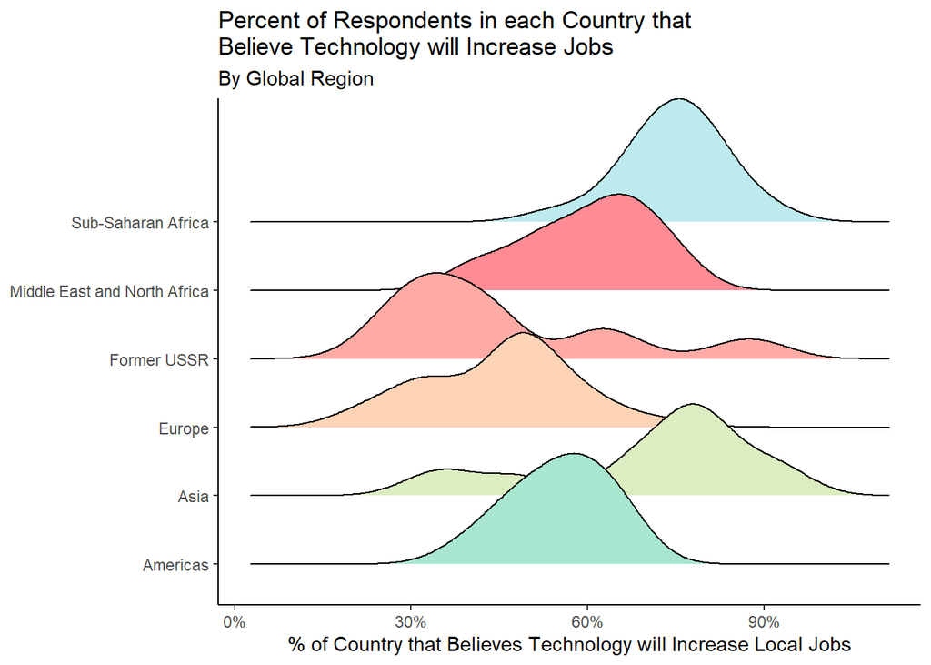

```r
#ridges plot
library(ggridges)

tech_data %>%
  ggplot(mapping = aes(x = percent_job, y = region, fill = region)) +
  geom_density_ridges() +
  scale_fill_manual(values = c('#a8e6cf', '#dcedc1', '#ffd3b6', '#ffaaa5', '#ff8b94', '#bdeaee'))+
  scale_x_continuous(labels = function(x) paste0(x, "%")) + # Add percent sign
  labs(x = "% of Country that Believes Technology will Increase Local Jobs",
       subtitle = "By Global Region") +
  theme_classic() +
  theme(legend.position = 'none',
        axis.title.y = element_blank()) +
  ggtitle("Percent of Respondents in each Country that \nBelieve Technology will Increase Jobs")
```